# Tornado first regression

Helen Greatrex

2021-07-26

# 1 Headings

## 1.1 sub-headings

### 1.1.1 sub-sub-heading (as long as there is a SPACE after the #)

we have space for text. Click insert (top right, then R)

```r
# load library
# if a library doesn't exist, then to download, go to the packages menu (next to help) and click install

# Upon downloading the .rmd file, I attempted to run this first code chunk and found that many of the libraries weren't installed.
#I needed to install each library before downloading it via this code

rm(list=ls())
library(sp)
library(sf)
library(raster)
library(tidycensus)
library(tidyverse)
library(plotly)
library(olsrr)
library(tmap)
library(RColorBrewer)
library("lubridate")
library(dplyr)
```

Write some more notes. Click preview to see a doc of the answer Look at Rstudio markdown tutorial for more cool stuff

```r
# dot . means current folder - and you don't need a file extension

# this code chunk uses "st_read" to read in the features from the initial tornado point shapefile
# the table/spreadsheet of data is saved to a variable "T_data"
T_data <- st_read(dsn="./1950-2019-torn-initpoint",
                  layer="1950-2019-torn-initpoint")
```

To see the data, you can click on its name, or make a code chunk and type View(T_data)

We can access individual columns using the $ symbol

```r
# columnn names, by the way, in a code chunk, the # means don't run this line
#this command displays all of the field names within the shapefile we read in with the previous code chunk
# the other way to think about it is that it's the column names in your spreadsheet.
names(T_data)
```

```
 [1] "om"       "yr"       "mo"       "dy"       "date"     "time"     "tz"       "st"       "stf"
[10] "stn"      "mag"      "inj"      "fat"      "loss"     "closs"    "slat"     "slon"     "elat"
[19] "elon"     "len"      "wid"      "fc"       "geometry"
```

```r
#summary gives details of each column of data within the shapefile
#some columns, date and time, are characters according to R
#we will need to convert these to a readable number in order to work with them and performa analysis

#summary(T_data)
```

```r
# print the 1st 6  values
#the head command displays the first six values from the selected column
#in this case we see the first 6 dates in the "date" columns
#R is interpreting these as characters, rather than a date
#we will need to convert them into something that R understands is a date

#head(T_data$date)
```

```r
#we use the head command here to give us the first 6 values for the entire data set
#additional information is provided around the metadata including geometry type, etc.

head(T_data)
```

[output not shown]

```r
# we need to find the format
# we look at the help file for strptime (this is not obvious)
#?strptime
```

```r
# make the date
# set the values in the date column to the variable "T_data$date"
#as.Date command converts the character data in the column to represent calendar dates
#calendar date is in the format year, month, date

T_data$date <- as.Date(T_data$date, format="%Y-%m-%d")
```

```r
#using the summary function again, we display all the data in the shapefile
#now the date column is displaying calendar dates rather than a character
#summary(T_data)
```

```r
# Let's cheat
head(T_data$time)
```

```
[1] "11:00:00" "11:55:00" "16:00:00" "05:25:00" "19:30:00" "21:00:00"
```

```r
# strsplit splits each character time string into a "list" (advent calendar) of the hour, minutes and seconds for each row
Fulltimes <- strsplit(T_data$time,":")


# Now we use the lapply function to make a new list with just the first one
# and we turn it back into just a normal row of numbers
T_data$hours   <-as.numeric(unlist(lapply(Fulltimes, "[",1)))
T_data$minutes <-as.numeric(unlist(lapply(Fulltimes, "[",2)))
T_data$seconds <-as.numeric(unlist(lapply(Fulltimes, "[",3)))
T_data$DecimalHour <- T_data$hours + (T_data$minutes/60)
```

```r
#using the summary function again, we display all the data in the shapefile
#now we see our new column "datetime"
#however, this is a character again
#we will need to convert this into something meaningful to analyze

#summary(T_data)
```

```r
# This is the number of tornados at each magnitude and each hour
table(T_data$hour,T_data$mag)
```

[output not shown]

```r
# I need to extract the hours and minutes from the $datetime column
#I found the code below which I think will help to get to the point where I will have the time value needed
#However, I am unsure how to match up what I see in the code below to our data

#I ran the code and it produces results but again, my confusion lies in how to translate the example code into something that works with #our data

#Time <- factor("08:01:01")

# parese date
#a <- hms(as.character(Time))

# get hours
#hour(a)

# get minutes
#minute(a)

# so overall - nice work
#a <- hms(T_data$time)
#T_data$hour <- hour(a)
#T_data$minutes <- minute(a)
```

# 2 Exploratory analysis

## 2.1 Bad magnitudes

We are now going to make some plots. First, let’s look at the time of day vs the magnitude, where the colour shows the number of tornados at that level

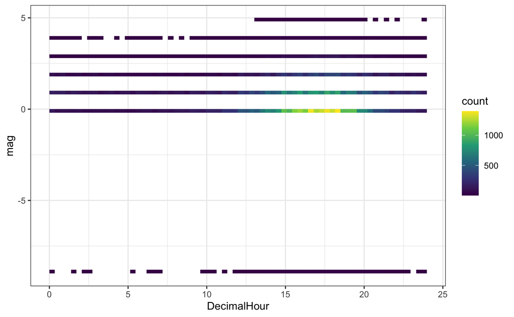

```r
# Bin size control + color palette
ggplot(T_data, aes(x=DecimalHour, y=mag) ) +
  geom_bin2d(bins = 70) +
  scale_fill_continuous(type = "viridis") +
  theme_bw()
```

### 2.1.1 Remove missing tornados

Some values in the magnitude column were -9. according to NOAA these were undetermined magnitude tornadoes, which we will remove from the data, as directed by https://www.spc.noaa.gov/wcm/data/SPC_severe_database_description.pdf

```r
# mag < 0 has been set to missing
T_data$mag[T_data$mag < 0 ] <- NA
```

So now, remake the plots

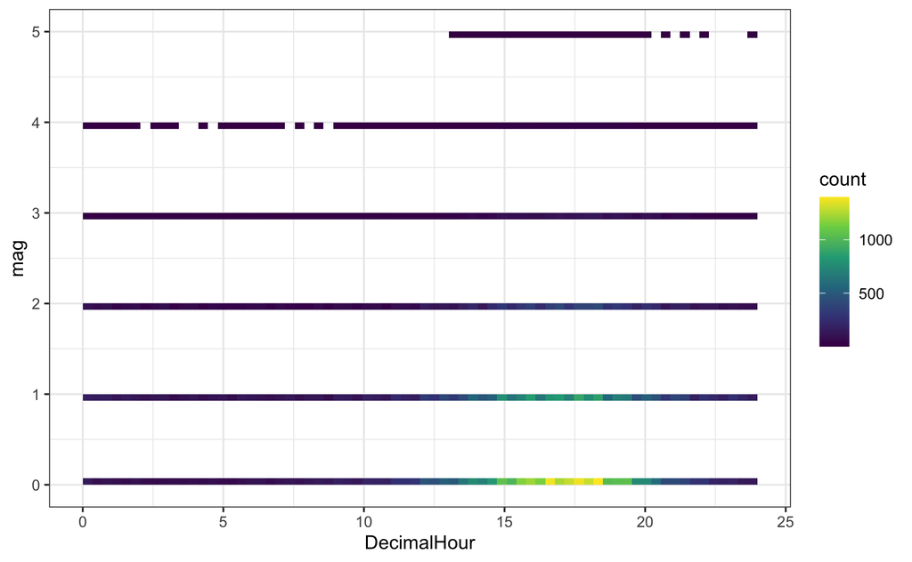

```r
# Bin size control + color palette
ggplot(T_data, aes(x=DecimalHour, y=mag) ) +
  geom_bin2d(bins = 70) +
  scale_fill_continuous(type = "viridis") +
  theme_bw()
```

# 3 More exploratory analysis

So now,fatalities by time of day

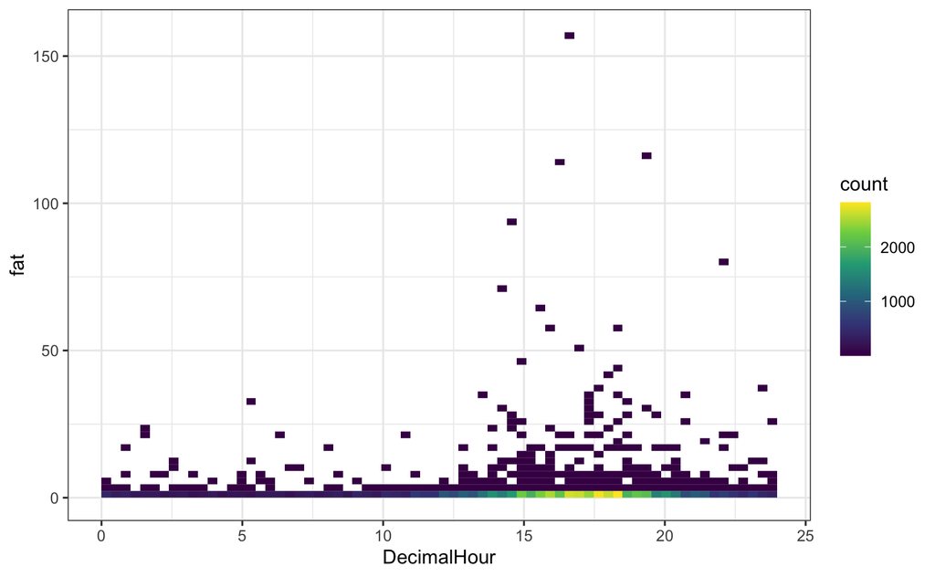

```r
# Bin size control + color palette
ggplot(T_data, aes(x=DecimalHour, y=fat) ) +
  geom_bin2d(bins = 70) +
  scale_fill_continuous(type = "viridis") +
  theme_bw()
```

### 3.0.1 REMEMBER WE WANT TO MAKE LIGHT LEVELS

# 4 What about the intersection between time of day and magnitude

Make a new table, with one row for each hour, then calculate the summary statistics. By the way the dplyr::summarise function is neater but helen doesn’t know it off by heart.

```r
TimeOfDay <- split(T_data,as.factor(T_data$hours))

TimeOfDaySummary <- data.frame(TimeOfDay        = sapply(split(T_data$hours,as.factor(T_data$hours)),"[",1),
                               NumberOfTornados = sapply(TimeOfDay,nrow),
                               TotalFatalities  = sapply(split(T_data$fat,as.factor(T_data$hours)),sum,na.rm=TRUE),
                               AvFatalities     = sapply(split(T_data$fat,as.factor(T_data$hours)),mean,na.rm=TRUE),
                               AvMag            = sapply(split(T_data$mag,as.factor(T_data$hours)),mean,na.rm=TRUE))


TimeOfDaySummary
```

|  | TimeOfDay | NumberOfTornados | TotalFatalities | AvFatalities | AvMag |
| --- | --- | --- | --- | --- | --- |
| 0 | 0 | 953 | 60 | 0.06295908 | 1.0283613 |
| 1 | 1 | 850 | 132 | 0.15529412 | 1.0318021 |
| 2 | 2 | 745 | 84 | 0.11275168 | 1.0672948 |
| 3 | 3 | 681 | 67 | 0.09838473 | 1.0616740 |
| 4 | 4 | 679 | 44 | 0.06480118 | 0.9837997 |
| 5 | 5 | 692 | 87 | 0.12572254 | 0.9971056 |
| 6 | 6 | 709 | 56 | 0.07898449 | 0.9532578 |
| 7 | 7 | 787 | 28 | 0.03557814 | 0.8398983 |
| 8 | 8 | 832 | 40 | 0.04807692 | 0.7656250 |
| 9 | 9 | 1017 | 20 | 0.01966568 | 0.7743842 |

[output cut: 14 more lines]

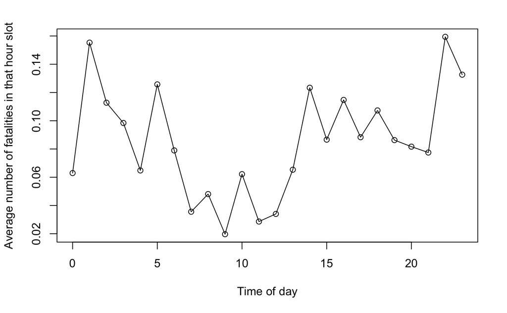

```r
# The ~ means "is a function of" e.g. y variable goes first

plot(TimeOfDaySummary$AvFatalities ~  TimeOfDaySummary$TimeOfDay,
     ylab="Average number of fatalities in that hour slot",
     xlab="Time of day",
     type="o")
```

## 4.1 Now let’s split into different magnitudes

### 4.1.1 CHOOSE A MAGNITUDE

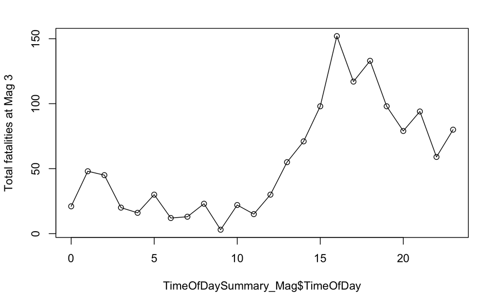

```r
#  YOU CHOOSE THE MAGNITUDE HERE

magnitude <- 3

# filter that mag
T_data_Mag <- filter(T_data,mag==magnitude)

# Split the data
TimeOfDay_Mag <- split(T_data_Mag,as.factor(T_data_Mag$hours))

# split by time of day as a summary table
TimeOfDaySummary_Mag <- data.frame(TimeOfDay   = sapply(split(T_data_Mag$hours,as.factor(T_data_Mag$hours)),"[",1),
                               NumberOfTornados = sapply(TimeOfDay_Mag,nrow),
                               TotalFatalities  = sapply(split(T_data_Mag$fat,as.factor(T_data_Mag$hours)),sum,na.rm=TRUE),
                               AvFatalities     = sapply(split(T_data_Mag$fat,as.factor(T_data_Mag$hours)),mean,na.rm=TRUE),
                               AvMag            = sapply(split(T_data_Mag$mag,as.factor(T_data_Mag$hours)),mean,na.rm=TRUE))


plot(TimeOfDaySummary_Mag$TotalFatalities ~  TimeOfDaySummary_Mag$TimeOfDay,
     ylab=paste("Total fatalities at Mag",magnitude),type="o")
```

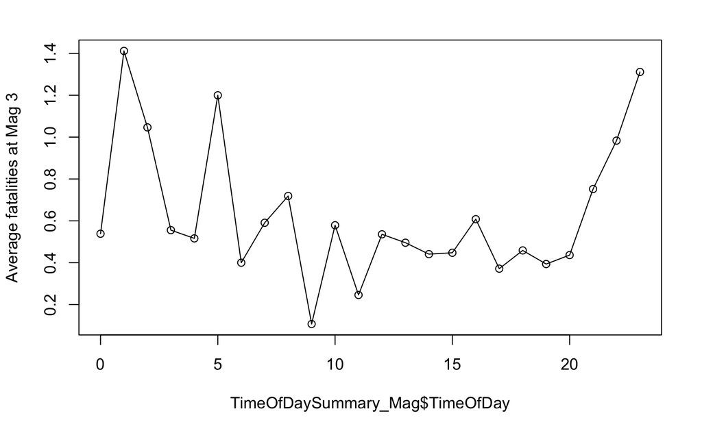

```r
plot(TimeOfDaySummary_Mag$AvFatalities ~  TimeOfDaySummary_Mag$TimeOfDay,
     ylab=paste("Average fatalities at Mag",magnitude),type="o")
```

TO DO: Look at the existing papers on time of day, did they scale by per tornado? or something else?

Add in extra mags and have a look, Start playing with other columns or making regressions..  
In words, now you have this, what’s interesting, THINK SPATIALLY Maybe do it as a powerpoint

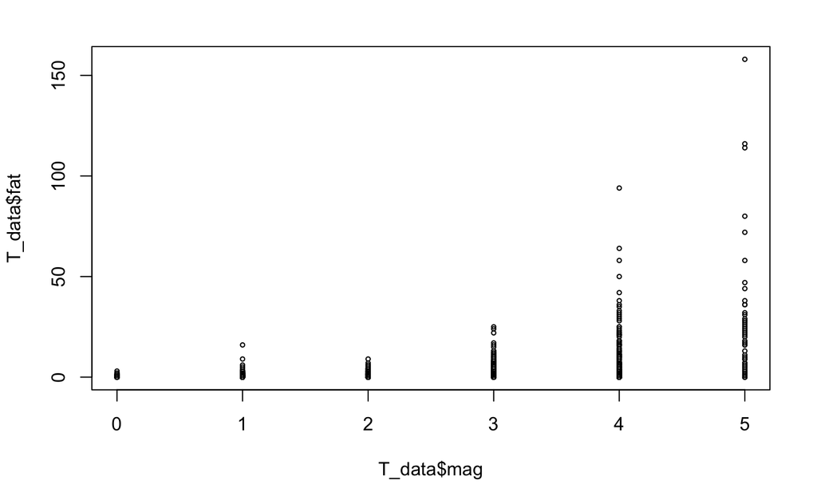

```r
# the tilda ~ means y depends on x... so fatalities (y axis) depend on time (x-axis)
# ignore time for now
plot(T_data$fat ~ T_data$mag,cex=.5)
```

this tutorial will be useful in honing code https://hgreatrex.github.io/lab-7.html#tutorial-2-regression

```r
#x,y

p <-  T_data %>%
  ggplot( aes(mag,fat,col= datetime,label=om)) +
  geom_point() +
  theme_classic()+
  scale_color_gradient(low="blue", high="red")

ggplotly(p)
```

```
Error in FUN(X[[i]], ...) : object 'datetime' not found
```

to do a regression